# TP modèles linéaires généralisés

4modIA - 2020-2021

Ce TP a pour but la révision des notions vues en modèle linéaire généralisé. Je vous invite à écrire les modèles, les tests, … mis en oeuvre tout le long du TP.  
Ce TP nécessite les librairies R suivantes :

```r
library(bestglm)
library(ggfortify)
library(ggplot2)
library(gridExtra)
library(VGAM)
library(ROCR)
```

Pour pouvoir compiler votre travail en fichier .html, pensez à enlever au fur et à mesure les balises “eval=F”.

# 1 Régression logistique

Dans cette section, nous allons nous intéresser au jeu de données `SAheart` disponible dans la librairie **bestglm**. On souhaite expliquer la présence/absence d’une maladie cardiovasculaire (*chd*) en fonction de 9 variables et on dispose pour cela d’un échantillon de $n=462$ individus.

```r
data(SAheart)
SAheart$chd<-as.factor(SAheart$chd)
```

## 1.1 Statistiques descriptives

Dans un premier temps, lisez la description des données disponible dans l’aide de R (tapez `? SAheart` dans la console). Faites une étude de statistique descriptive pour vous familiariser avec le jeu de données.

```r
str(SAheart)
```

```
'data.frame':   462 obs. of  10 variables:
 $ sbp      : int  160 144 118 170 134 132 142 114 114 132 ...
 $ tobacco  : num  12 0.01 0.08 7.5 13.6 6.2 4.05 4.08 0 0 ...
 $ ldl      : num  5.73 4.41 3.48 6.41 3.5 6.47 3.38 4.59 3.83 5.8 ...
 $ adiposity: num  23.1 28.6 32.3 38 27.8 ...
 $ famhist  : Factor w/ 2 levels "Absent","Present": 2 1 2 2 2 2 1 2 2 2 ...
 $ typea    : int  49 55 52 51 60 62 59 62 49 69 ...
 $ obesity  : num  25.3 28.9 29.1 32 26 ...
 $ alcohol  : num  97.2 2.06 3.81 24.26 57.34 ...
 $ age      : int  52 63 46 58 49 45 38 58 29 53 ...
 $ chd      : Factor w/ 2 levels "0","1": 2 2 1 2 2 1 1 2 1 2 ...
```

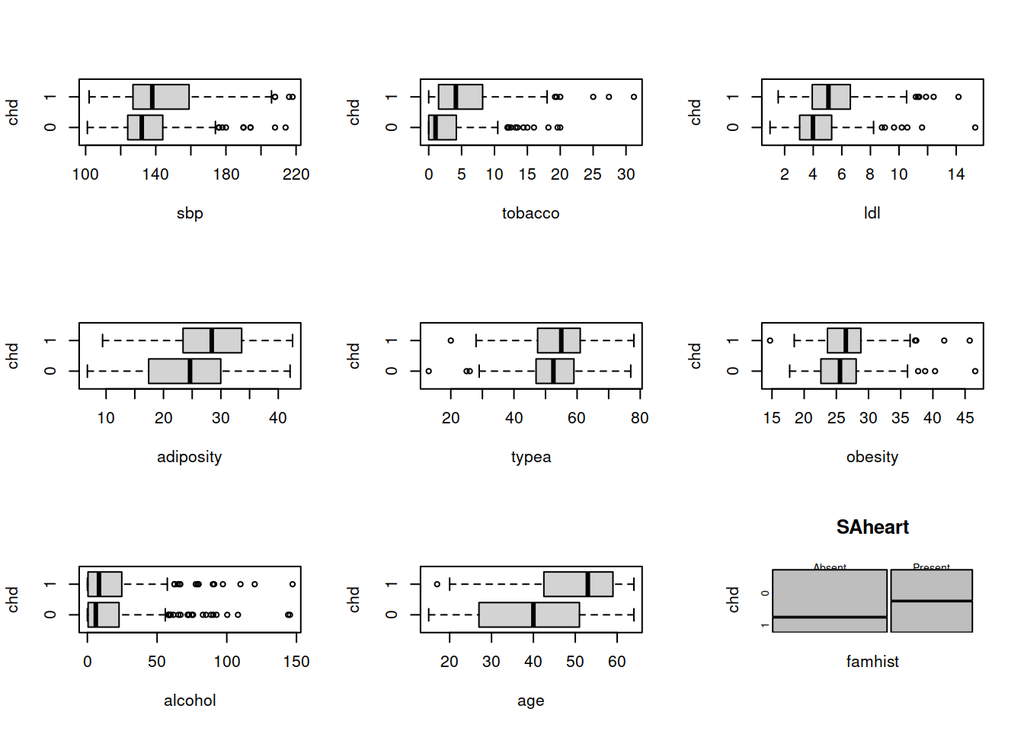

```r
par(mfrow=c(3,3))
boxplot(sbp ~ chd, SAheart, horizontal = T)
boxplot(tobacco ~ chd, SAheart, horizontal = T)
boxplot(ldl ~ chd, SAheart, horizontal = T)
boxplot(adiposity ~ chd, SAheart, horizontal = T)
boxplot(typea ~ chd, SAheart, horizontal = T)
boxplot(obesity ~ chd, SAheart, horizontal = T)
boxplot(alcohol ~ chd, SAheart, horizontal = T)
boxplot(age ~ chd, SAheart, horizontal = T)
mosaicplot(famhist ~ chd, SAheart)
```

Le jeu de données contient 10 variables (8 quantitatives et 2 qualitative) pour 462 individus.

## 1.2 Etude de *chd* en fonction de la variable *ldl*

1. Proposez un modèle pour expliquer *chd* en fonction de *ldl* et programmez-le à l’aide de la fonction `glm()`

$$chd_i \sim \mathcal{B}(\pi_i)$$
$$logit(\pi_i) = \ln\left(\frac{\pi_i}{1-\pi_i}\right) = \theta_0 + \theta_1 ldl_i$$

```r
chd_ldl = glm(chd~ldl, data = SAheart, family = binomial(link = "logit"))
summary(chd_ldl)
```

```
Call:
glm(formula = chd ~ ldl, family = binomial(link = "logit"), data = SAheart)

Deviance Residuals:
    Min       1Q   Median       3Q      Max
-2.1647  -0.8948  -0.7426   1.2688   1.8637

Coefficients:
            Estimate Std. Error z value Pr(>|z|)
(Intercept) -1.96867    0.27308  -7.209 5.63e-13 ***
ldl          0.27466    0.05164   5.319 1.04e-07 ***
---
Signif. codes:  0 '***' 0.001 '**' 0.01 '*' 0.05 '.' 0.1 ' ' 1

(Dispersion parameter for binomial family taken to be 1)

    Null deviance: 596.11  on 461  degrees of freedom
Residual deviance: 564.28  on 460  degrees of freedom
AIC: 568.28

Number of Fisher Scoring iterations: 4
```

2. A l’aide des sorties de `chd_ldl`, calculez le pseudoR2 associé à ce modèle et commentez.

```r
pseudoR2 = 1 - chd_ldl$deviance/chd_ldl$null.deviance
pseudoR2
```

```
[1] 0.05339565
```

Le pseudo $R^2$ est proche de 0, donc l’ajustement du modèle aux données est très mauvais. On va devoir aller chercher d’autres variables pour prédire notre résultat.

3. Testez la nullité de chacun des paramètres dans ce modèle par deux méthodes différentes et concluez à l’aide des sorties de R. Vous pouvez utiliser la fonction `anova()` avec l’option `test="Chisq"`.

```r
anova(glm(chd~1, data = SAheart, family = binomial(link = "logit")), test="Chisq", chd_ldl)
```

```
Analysis of Deviance Table

Model 1: chd ~ 1
Model 2: chd ~ ldl
  Resid. Df Resid. Dev Df Deviance  Pr(>Chi)
1       461     596.11
2       460     564.28  1    31.83 1.683e-08 ***
---
Signif. codes:  0 '***' 0.001 '**' 0.01 '*' 0.05 '.' 0.1 ' ' 1
```

```r
summary(chd_ldl)$coef
```

```
              Estimate Std. Error   z value     Pr(>|z|)
(Intercept) -1.9686681 0.27307908 -7.209150 5.630207e-13
ldl          0.2746613 0.05163983  5.318787 1.044615e-07
```

On trouve deux p-valeurs différentes : `1.683e-08` et `1.04e-07`. Nous n’avons pas la même valeur car en MLG, les p-valeurs sont approximées asymptotiquement, ce qui peut engendrer un décalage selon le test utilisé. Ces deux valeurs sont cependant très faibles dans les deux cas, et on rejette $\mathcal{H}_0$ au risque $5\%$, c’est à dire qu’on conserve la variable `ldl`.

4. Construisez un intervalle de confiance au niveau de confiance de $95\%$ pour les paramètres de ce modèle et programmez-les à l’aide des fonctions `confint()` (rapport de vraisemblance) et `confint.default()` (méthode de Wald).

```r
confint(chd_ldl)
```

```
                 2.5 %     97.5 %
(Intercept) -2.5190571 -1.4468069
ldl          0.1760264  0.3788656
```

```r
confint.default(chd_ldl)
```

```
                 2.5 %     97.5 %
(Intercept) -2.5038933 -1.4334430
ldl          0.1734491  0.3758735
```

5. Interprétez les paramètres à l’aide d’odds et/ou d’odds ratio.

```r
summary(chd_ldl)$coef
```

```
              Estimate Std. Error   z value     Pr(>|z|)
(Intercept) -1.9686681 0.27307908 -7.209150 5.630207e-13
ldl          0.2746613 0.05163983  5.318787 1.044615e-07
```

```r
exp(summary(chd_ldl)$coef)
```

```
             Estimate Std. Error      z value Pr(>|z|)
(Intercept) 0.1396427   1.314004 7.397855e-04        1
ldl         1.3160848   1.052996 2.041361e+02        1
```

$$odds(ldl = 0) = e^{\theta_0} \approx e^{-1.9686681}= 0.1396$$

Si l’on n’a que des variables quantitatives, pas d’interprétation pour l’intercept.

$$OR(ldl + 1, ldl) = \frac{odds(ldl + 1)}{odds(ldl)} = \frac{e^{\theta_0 + \theta_1(ldl+1)}}{e^{\theta_0 + \theta_1 ldl}} = e^{\theta_1} \approx e^{0.2746613} = 1.3161$$

Si on augmente le `ldl` d’une unité, on a 1.32 fois plus de chance d’avoir un infarctus.

6. Que permettent d’obtenir les deux commandes suivantes ?

On prend un nouvel individu de $ldl = 4.75$.

```r
predict(chd_ldl,newdata=data.frame(ldl=4.75),type="link")       # partie linéaire
```

```
         1
-0.6640271
```

```r
a = chd_ldl$coefficients[1] + chd_ldl$coefficients[2]*4.75 ; a
```

```
(Intercept)
 -0.6640271
```

```r
predict(chd_ldl,newdata=data.frame(ldl=4.75),type="response")   # après application du logit
```

```
        1
0.3398356
```

```r
exp(a)/(1+exp(a))
```

```
(Intercept)
  0.3398356
```

7. Déterminez les valeurs ajustées à l’aide de la fonction `predict()`. Comparez les valeurs ajustées avec les vraies valeurs de *chd* par une table de contingence (vous pouvez utiliser la fonction `table()`).

Vous pouvez visualiser les résultats à l’aide des commandes suivantes :

```r
pihat<-predict(chd_ldl,type="response")
Yhat = (chd_ldl$fitted.values > 0.5)
table(SAheart$chd, Yhat)
```

```
   Yhat
    FALSE TRUE
  0   277   25
  1   129   31
```

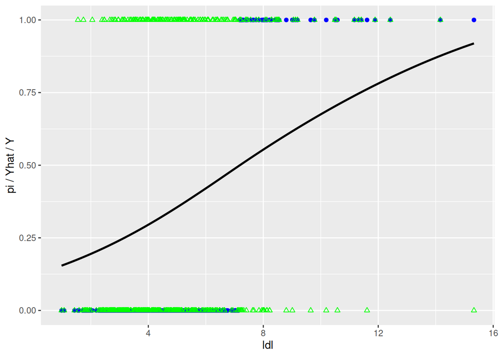

```r
df1<-data.frame(ldl=SAheart$ldl,pihat=pihat,
         Yihat=as.numeric(pihat > 0.5) ,
         Yi=as.numeric(SAheart$chd)-1)

ggplot(df1)+
geom_point(aes(x=ldl,y=Yihat),col="blue")+
geom_smooth(aes(x=ldl,y=pihat),col="black")+
geom_point(aes(x=ldl,y=Yi),col="green",shape=2)+
xlab("ldl")+
ylab("pi / Yhat / Y")
```

## 1.3 Etude de *chd* en fonction de la variable *famhist*

1. Proposez un modèle pour expliquer *chd* en fonction de *famhist* et programmez-le à l’aide de la fonction `glm()`.

$$chd_i \sim \mathcal{B}(\pi_i)$$
$$g(\pi_i) = \ln\left(\frac{\pi_i}{1-\pi_i}\right) = \theta_0 + \theta_1 \mathbb{1}_{famhist = 1}$$

```r
chd_famhist = glm(chd ~ famhist, data = SAheart, family = binomial(link = "logit"))
summary(chd_famhist)
```

```
Call:
glm(formula = chd ~ famhist, family = binomial(link = "logit"),
    data = SAheart)

Deviance Residuals:
    Min       1Q   Median       3Q      Max
-1.1774  -0.7356  -0.7356   1.1774   1.6968

Coefficients:
               Estimate Std. Error z value Pr(>|z|)
(Intercept)     -1.1690     0.1431  -8.169 3.12e-16 ***
famhistPresent   1.1690     0.2033   5.751 8.85e-09 ***
---
Signif. codes:  0 '***' 0.001 '**' 0.01 '*' 0.05 '.' 0.1 ' ' 1

(Dispersion parameter for binomial family taken to be 1)

    Null deviance: 596.11  on 461  degrees of freedom
Residual deviance: 561.89  on 460  degrees of freedom
AIC: 565.89

Number of Fisher Scoring iterations: 4
```

2. Que remarquez-vous sur l’estimation des paramètres ? Quel est l’impact sur les prédictions ?

```r
summary(chd_famhist)$coef
```

```
                Estimate Std. Error   z value     Pr(>|z|)
(Intercept)    -1.168993  0.1431060 -8.168720 3.116788e-16
famhistPresent  1.168993  0.2032552  5.751357 8.853003e-09
```

3. Calculez l’odds ratio associé à la variable `famhist` et interprétez.

```r
exp(c(coef(chd_famhist), sum = sum(coef(chd_famhist))))
```

```
   (Intercept) famhistPresent            sum
     0.3106796      3.2187500      1.0000000
```